# Example: Deshka 2018 Forecast

Adam Reimer

January 12, 2018

## Introduction

This example will use the Deshka River Chinook salmon brood table to demonstrate preseason salmon forecasts in R. The process is similar to the SAS/Excel workflow we have traditionally used but offers improved repeatability, improved cross validation for model selection and offer a flexible framework where other models can be considered easily. The functions used in this tutorial are all part of the “preseason” package available on GitHub. To get the package first install the package “devtools” then run the following code in R:

```r
devtools::install_github("adamreimer/preseason")
```

```r
library(preseason)
```

If it worked you should be able to see the Deshka brood table by typing.

```r
deshka[1:dim(deshka)[1], ]
```

```
##     byr     S age3  age4  age5  age6 age7
## 1  1974 15201    0  7311 38602 15451    0
## 2  1975 14088    0  4504 20206  8842    0
## 3  1976 48916    0  3962 15272 18526    0
## 4  1977 85784    0  2679 19388 16471    0
## 5  1978 54967    0  5601 22862 16405   24
## 6  1979 60607    0 10469 21417 20498  106
## 7  1980 35096    0  7747 21271 15979   19
## 8  1981 23162    0  7232 23705 12990 1017
## 9  1982 37222    0 19192 24362 31447  423
## 10 1983 43871   40  7183 13260 15609  189
## 11 1984 39054   15  6415  8772 19974    1
## 12 1985 41640  495  8405 22338 15905   15
## 13 1986 47657  513  8768 11060 10566    9
## 14 1987 35226  474  4906  8952  7367  101
```

[output cut: 30 more lines]

Please reveiw and make sure you are happy with this version. We should probably consider if age 3 zeros are actual zeros or NA’s, which we could interpret as “not monitored”.

To begin we prepare the brood table for analysis in each age class using the function “prep_brood”. In the output the column “lnRS” is relative the oldest age included in the table and years without complete broods relative to the oldest age in the table are removed.

```r
dat4 <- prep_brood(deshka, age_range = 3:4)
tail(dat4)
```

```
## # A tibble: 6 x 7
##     byr     S  age3  age4       lnRS  age3_ln  age4_ln
##   <dbl> <dbl> <dbl> <dbl>      <dbl>    <dbl>    <dbl>
## 1  2008  7284   519  8809  0.1900938 6.251904 9.083529
## 2  2009 11641   669  4278 -1.0010477 6.505784 8.361241
## 3  2010 18223   785  7046 -0.9502245 6.665684 8.860215
## 4  2011 18553  1550  7211 -0.9450239 7.346010 8.883363
## 5  2012 13952  2897 11021 -0.2358203 7.971431 9.307558
## 6  2013 18378  4029  1706 -2.3770028 8.301273 7.441907
```

```r
dat5 <- prep_brood(deshka, age_range = 3:5)
tail(dat5)
```

```
## # A tibble: 6 x 9
##     byr     S  age3  age4  age5       lnRS  age3_ln  age4_ln  age5_ln
##   <dbl> <dbl> <dbl> <dbl> <dbl>      <dbl>    <dbl>    <dbl>    <dbl>
## 1  2007 17594   200  6031  4182 -1.4367683 5.298317 8.704668 8.338545
## 2  2008  7284   519  8809 11682  0.4723690 6.251904 9.083529 9.365804
## 3  2009 11641   669  4278  7108 -0.4933124 6.505784 8.361241 8.868976
## 4  2010 18223   785  7046 12763 -0.3561342 6.665684 8.860215 9.454306
## 5  2011 18553  1550  7211  8948 -0.7292015 7.346010 8.883363 9.099185
## 6  2012 13952  2897 11021  9391 -0.3958711 7.971431 9.307558 9.147507
```

```r
dat6 <- prep_brood(deshka, age_range = 4:6)
tail(dat6)
```

```
## # A tibble: 6 x 9
##     byr     S  age4  age5  age6      lnRS  age4_ln  age5_ln  age6_ln
##   <dbl> <dbl> <dbl> <dbl> <dbl>     <dbl>    <dbl>    <dbl>    <dbl>
## 1  2006 29922  4668 14461  2453 -2.501282 8.448486 9.579211 7.805067
## 2  2007 17594  6031  4182  3282 -1.679105 8.704668 8.338545 8.096208
## 3  2008  7284  8809 11682  2197 -1.198587 9.083529 9.365804 7.694848
## 4  2009 11641  4278  7108  3332 -1.250961 8.361241 8.868976 8.111328
## 5  2010 18223  7046 12763  1787 -2.322146 8.860215 9.454306 7.488294
## 6  2011 18553  7211  8948  1313 -2.648317 8.883363 9.099185 7.180070
```

We will primarily work with the logs of abundance (suffix “_ln“) because normal distributions that fit these data include negative run sizes.

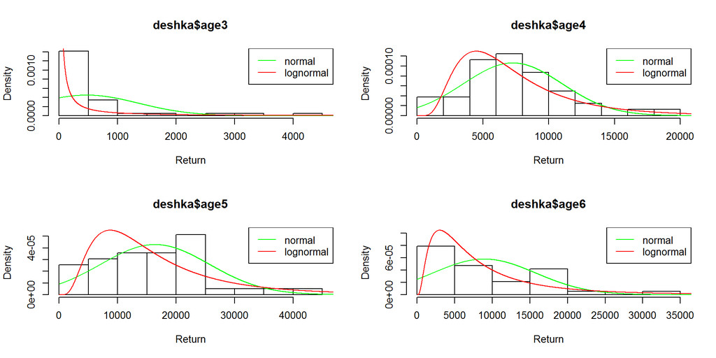

```r
par(mfrow = c(2,2))
plot_dist(deshka$age3)
plot_dist(deshka$age4)
plot_dist(deshka$age5)
plot_dist(deshka$age6)
```

```r
par(mfrow = c(1,1))
```

## Sibling models

### Age 4

The sibling model was insignificant for age 4 fish so let’s move on.

```r
sib4 <- lm(age4_ln ~ age3, data = dat4)
summary(sib4)
```

```
##
## Call:
## lm(formula = age4_ln ~ age3, data = dat4)
##
## Residuals:
##     Min      1Q  Median      3Q     Max
## -1.4545 -0.3286  0.1080  0.3413  1.0859
##
## Coefficients:
##               Estimate Std. Error t value Pr(>|t|)
## (Intercept)  8.776e+00  1.047e-01  83.821   <2e-16 ***
## age3        -7.311e-05  1.048e-04  -0.697     0.49
## ---
## Signif. codes:  0 '***' 0.001 '**' 0.01 '*' 0.05 '.' 0.1 ' ' 1
##
## Residual standard error: 0.5899 on 38 degrees of freedom
## Multiple R-squared:  0.01263,    Adjusted R-squared:  -0.01335
## F-statistic: 0.4863 on 1 and 38 DF,  p-value: 0.4898
```

### Age 5

For age 5 fish we get a significant model with decent looking residuals.

```r
sib5 <- lm(age5_ln ~ age4_ln + age3, data = dat5)
summary(sib5)
```

```
##
## Call:
## lm(formula = age5_ln ~ age4_ln + age3, data = dat5)
##
## Residuals:
##      Min       1Q   Median       3Q      Max
## -1.16620 -0.29570  0.01038  0.31257  1.03440
##
## Coefficients:
##               Estimate Std. Error t value Pr(>|t|)
## (Intercept)  1.6813784  1.1491856   1.463   0.1521
## age4_ln      0.9066827  0.1313386   6.903  4.4e-08 ***
## age3        -0.0003450  0.0001041  -3.314   0.0021 **
## ---
## Signif. codes:  0 '***' 0.001 '**' 0.01 '*' 0.05 '.' 0.1 ' ' 1
##
## Residual standard error: 0.4421 on 36 degrees of freedom
## Multiple R-squared:  0.593,  Adjusted R-squared:  0.5704
## F-statistic: 26.23 on 2 and 36 DF,  p-value: 9.378e-08
```

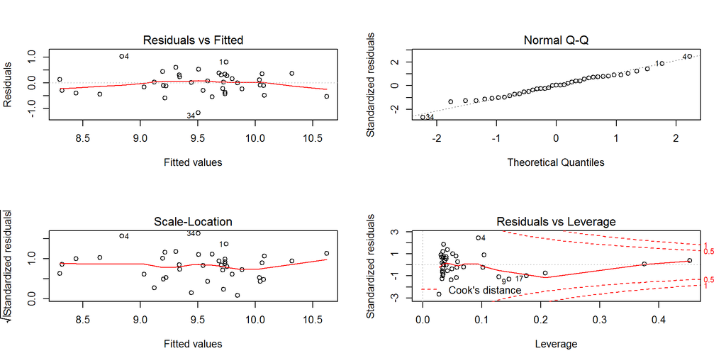

```r
par(mfrow = c(2,2)); plot(sib5); par(mfrow = c(1,1))
```

Here is a look at the data, the trend for age 3 is pretty obvious but again, maybe those 0’s aren’t real.

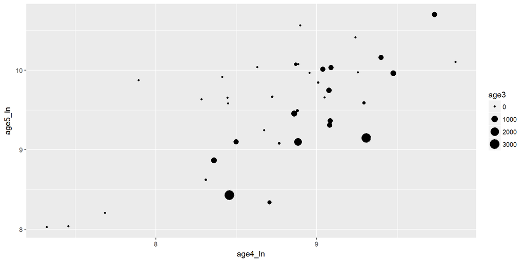

```r
ggplot2::ggplot(dat5, ggplot2::aes(x = age4_ln, y = age5_ln, size = age3)) + ggplot2::geom_point()
```

I don’t see any residual correlation either.

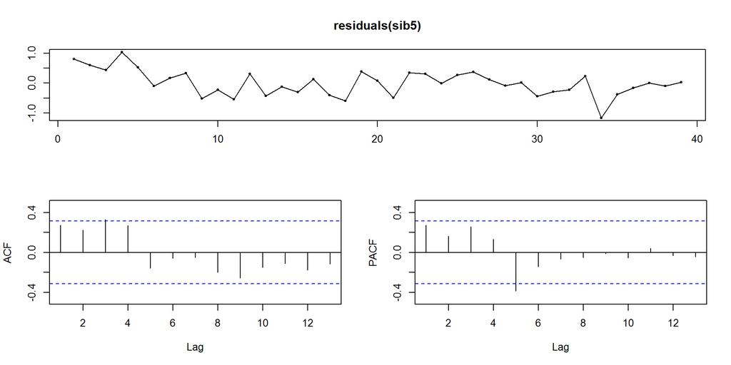

```r
forecast::tsdisplay(residuals(sib5))
```

The function “pred_lm produces predictions for each year with all of the data except the data for that year using a linear model. We can save those to the original dataframe with the name”sib_pred" where the suffix “_pred" is important (a later function will look for variables with that suffix to preform comparisons.)

```r
temp <- pred_lm(sib5)
dat5$sib_pred <- exp(temp[1,] + temp[2,]^2/2)
```

### Age 6

Here is a sibling model for age 6 fish.

```r
sib6 <- lm(age6_ln ~ age5_ln + age4_ln, data = dat6)
summary(sib6)
```

```
##
## Call:
## lm(formula = age6_ln ~ age5_ln + age4_ln, data = dat6)
##
## Residuals:
##     Min      1Q  Median      3Q     Max
## -1.4674 -0.3572 -0.0450  0.4654  1.5352
##
## Coefficients:
##             Estimate Std. Error t value Pr(>|t|)
## (Intercept)   2.1558     1.9519   1.104  0.27693
## age5_ln       0.8821     0.2497   3.533  0.00118 **
## age4_ln      -0.2050     0.3067  -0.669  0.50818
## ---
## Signif. codes:  0 '***' 0.001 '**' 0.01 '*' 0.05 '.' 0.1 ' ' 1
##
## Residual standard error: 0.7277 on 35 degrees of freedom
## Multiple R-squared:  0.3558, Adjusted R-squared:  0.319
## F-statistic: 9.664 on 2 and 35 DF,  p-value: 0.0004551
```

Note that there is no sibling relationship between the 4’s and the 6’s so let’s reduce the model.

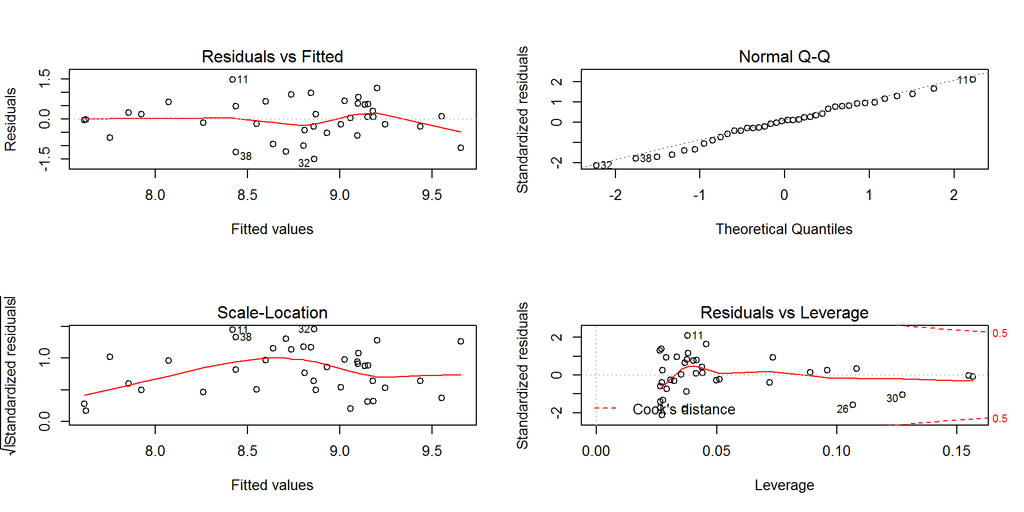

```r
sib6 <- update(sib6, formula. = . ~ age5_ln)
par(mfrow = c(2,2)); plot(sib6); par(mfrow = c(1,1))
```

This time we see significant residual correlation with a trend. The best fitting time series model is a AR1 model with differencing. The function “pred_arima” produces predictions for each year using a arima model and only the data prior to the predicted year. Let’s run that and save those predictions as well.

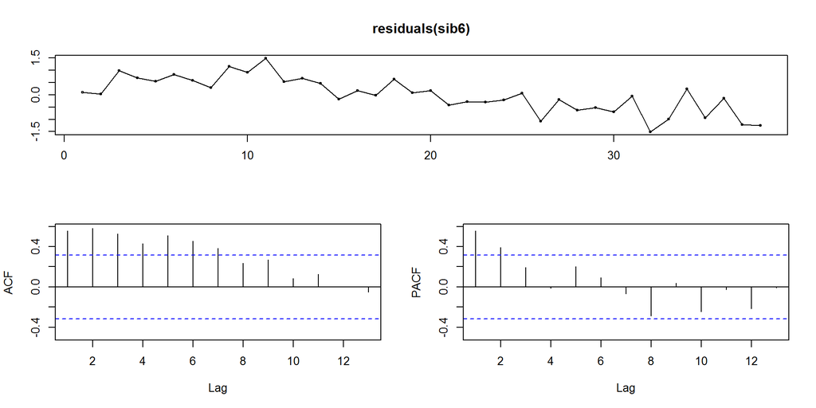

```r
forecast::tsdisplay(residuals(sib6))
```

```r
forecast::auto.arima(dat6$age6_ln, xreg = dat6$age5_ln)
```

```
## Series: dat6$age6_ln
## Regression with ARIMA(1,1,0) errors
##
## Coefficients:
##           ar1    xreg
##       -0.5315  0.3725
## s.e.   0.1404  0.1094
##
## sigma^2 estimated as 0.2094:  log likelihood=-22.72
## AIC=51.43   AICc=52.16   BIC=56.26
```

```r
sib6_arima <- arima(dat6$age6_ln, c(1,1,0), xreg = dat6$age5_ln)
temp <- pred_arima(sib6_arima, x = dat6$age6_ln, xreg = dat6$age5_ln)
dat6$sib6_pred <- exp(temp[1,] + temp[2,]^2/2)
```

Rich was big on subsetting the data for sibling models which should be easy to accomplish if you are interested.

## Ricker models

### Age 4

The age 4 Ricker model looks good with no residual correlation so save the predictions with the “pred_lm” function.

```r
rick4 <- lm(lnRS ~ S, data = dat4)
summary(rick4)
```

```
##
## Call:
## lm(formula = lnRS ~ S, data = dat4)
##
## Residuals:
##     Min      1Q  Median      3Q     Max
## -1.4378 -0.3386  0.0397  0.3230  1.0432
##
## Coefficients:
##               Estimate Std. Error t value Pr(>|t|)
## (Intercept) -1.919e-01  1.984e-01  -0.967     0.34
## S           -4.067e-05  5.652e-06  -7.196 1.34e-08 ***
## ---
## Signif. codes:  0 '***' 0.001 '**' 0.01 '*' 0.05 '.' 0.1 ' ' 1
##
## Residual standard error: 0.5851 on 38 degrees of freedom
## Multiple R-squared:  0.5768, Adjusted R-squared:  0.5656
## F-statistic: 51.78 on 1 and 38 DF,  p-value: 1.338e-08
```

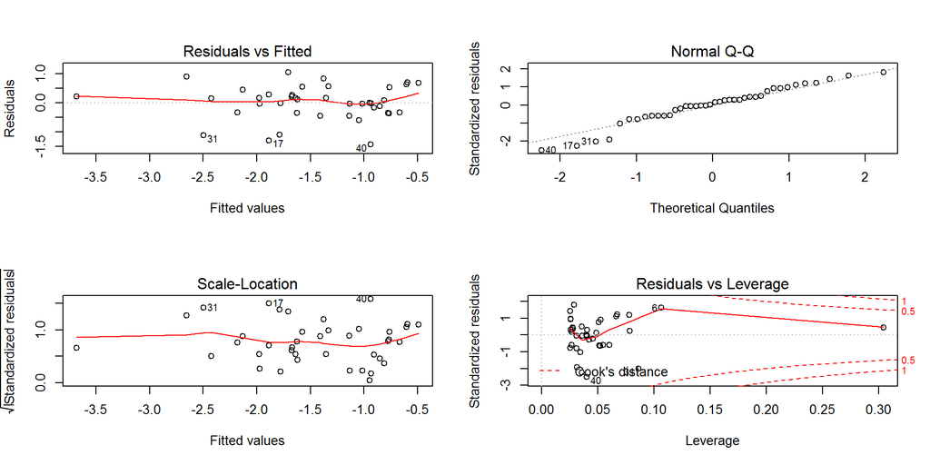

```r
par(mfrow = c(2,2)); plot(rick4); par(mfrow = c(1,1))
```

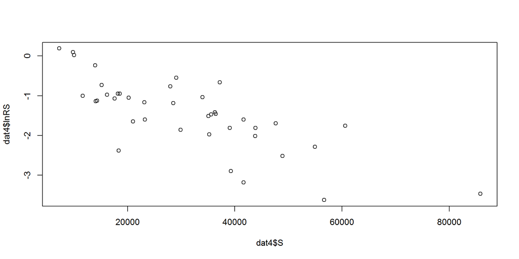

```r
plot(dat4$S, dat4$lnRS)
```

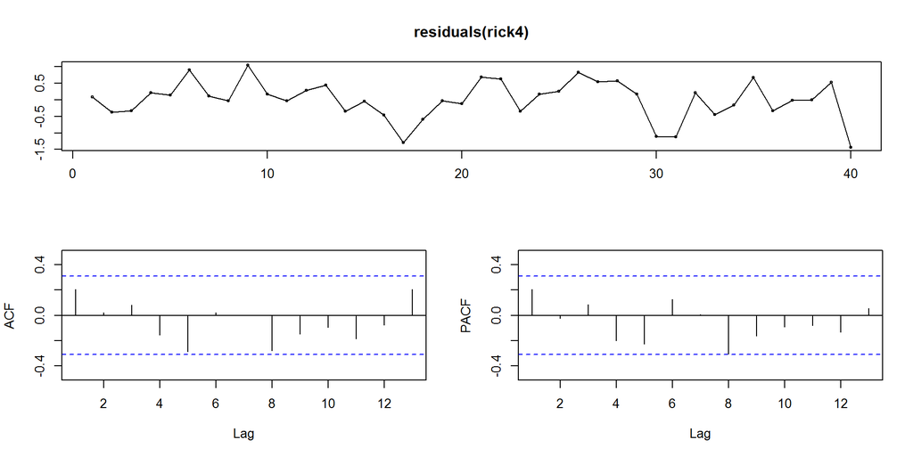

```r
forecast::tsdisplay(residuals(rick4))
```

```r
dat4$ricker_pred <- exp(pred_lm(rick4)[1,]) * dat4$S
```

### Age 5

The age 5 Ricker model also looks good but has some residual correlation.

```r
rick5 <- lm(lnRS ~ S, data = dat5)
summary(rick5)
```

```
##
## Call:
## lm(formula = lnRS ~ S, data = dat5)
##
## Residuals:
##     Min      1Q  Median      3Q     Max
## -1.5587 -0.3966  0.1561  0.4533  1.1709
##
## Coefficients:
##               Estimate Std. Error t value Pr(>|t|)
## (Intercept)  3.626e-01  2.469e-01   1.469     0.15
## S           -3.366e-05  6.968e-06  -4.831 2.38e-05 ***
## ---
## Signif. codes:  0 '***' 0.001 '**' 0.01 '*' 0.05 '.' 0.1 ' ' 1
##
## Residual standard error: 0.7158 on 37 degrees of freedom
## Multiple R-squared:  0.3868, Adjusted R-squared:  0.3702
## F-statistic: 23.34 on 1 and 37 DF,  p-value: 2.376e-05
```

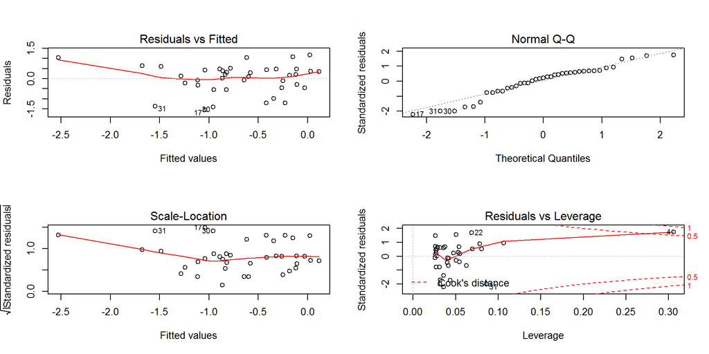

```r
par(mfrow = c(2,2)); plot(rick5); par(mfrow = c(1,1))
```

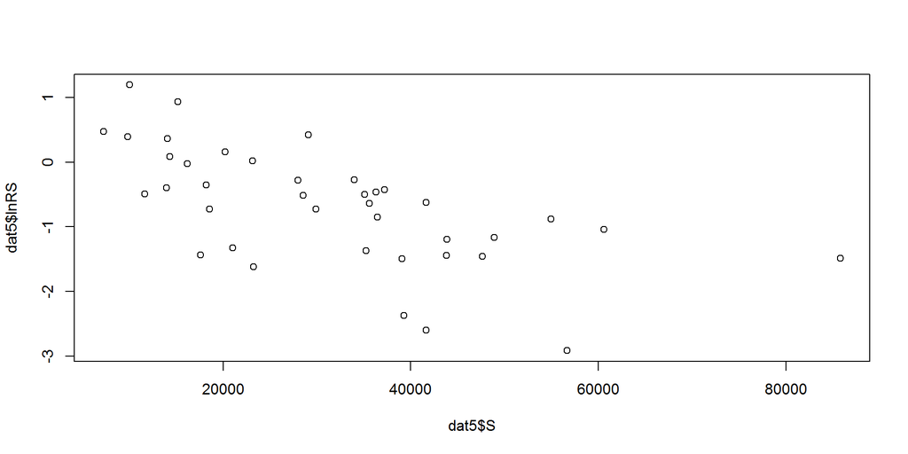

```r
plot(dat5$S, dat5$lnRS)
```

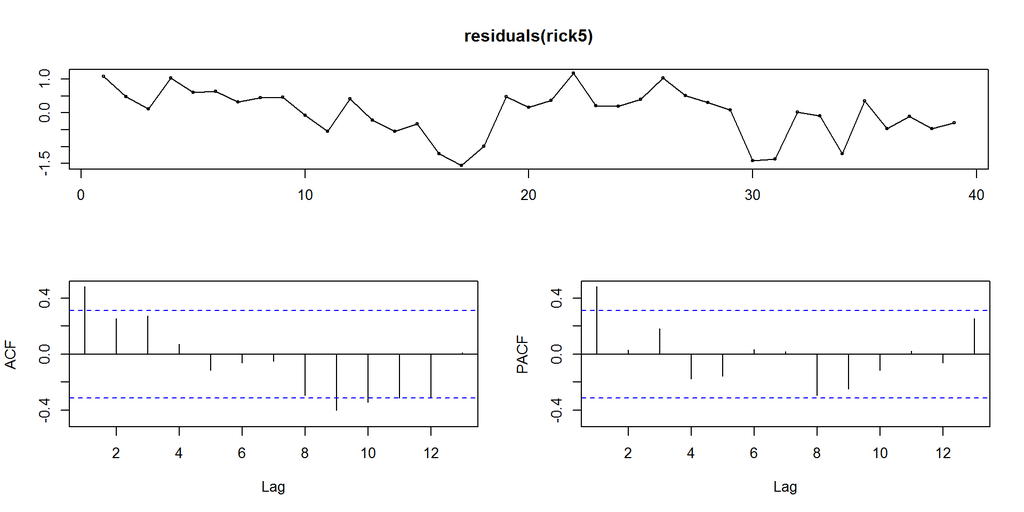

```r
forecast::tsdisplay(residuals(rick5))
```

Looks like and AR1 process is the best fit, save the predictions using the “pred_arima” function.

```r
forecast::auto.arima(dat5$lnRS, xreg = dat5$S)
```

```
## Series: dat5$lnRS
## Regression with ARIMA(1,0,0) errors
##
## Coefficients:
```

```
##          ar1  xreg
##       0.5258     0
## s.e.     NaN   NaN
##
## sigma^2 estimated as 0.4045:  log likelihood=-36.82
## AIC=79.65   AICc=80.34   BIC=84.64
```

```r
rick5_ar1 <- arima(dat5$lnRS, order=c(1,0,0), xreg = dat5$S)
AIC(rick5, rick5_ar1)
```

```
##           df      AIC
## rick5      3 88.54978
## rick5_ar1  4 79.63739
```

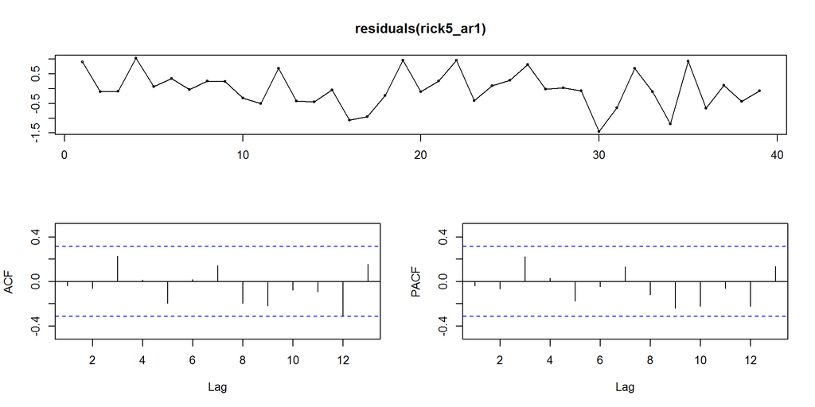

```r
forecast::tsdisplay(residuals(rick5_ar1))
```

```r
dat5$ricker_pred <- exp(pred_arima(rick5_ar1, x = dat5$lnRS, xreg = dat5$S)[1,]) * dat5$S
```

### Age 6

The age 6 Ricker model is insignificant.

```r
rick6 <- lm(lnRS ~ S, data = dat6)
summary(rick6)
```

```
##
## Call:
## lm(formula = lnRS ~ S, data = dat6)
##
## Residuals:
##     Min      1Q  Median      3Q     Max
## -1.9487 -0.4348  0.1552  0.6477  1.3787
##
## Coefficients:
##               Estimate Std. Error t value Pr(>|t|)
## (Intercept) -9.818e-01  3.080e-01  -3.188  0.00296 **
## S           -1.519e-05  8.597e-06  -1.767  0.08569 .
## ---
## Signif. codes:  0 '***' 0.001 '**' 0.01 '*' 0.05 '.' 0.1 ' ' 1
##
## Residual standard error: 0.8701 on 36 degrees of freedom
## Multiple R-squared:  0.07982,    Adjusted R-squared:  0.05426
## F-statistic: 3.123 on 1 and 36 DF,  p-value: 0.08569
```

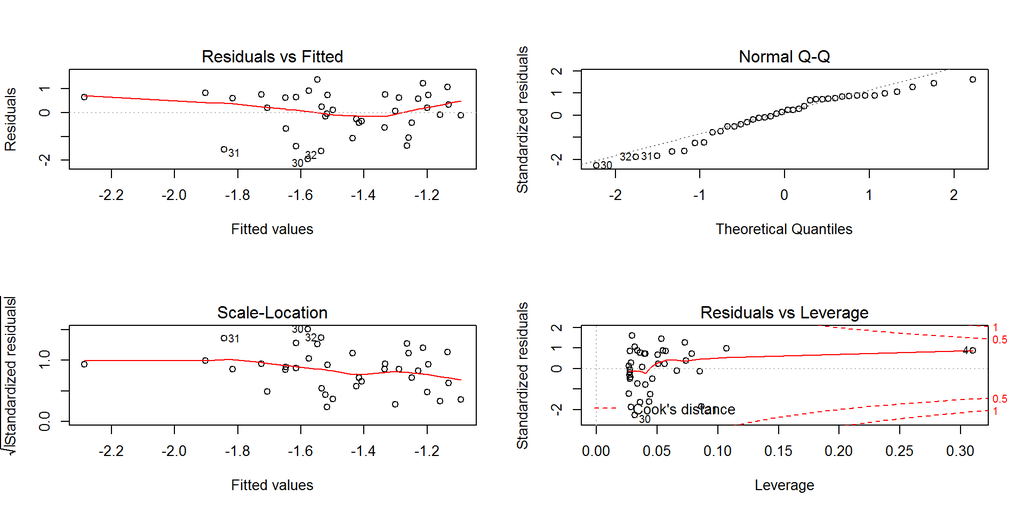

```r
par(mfrow = c(2,2)); plot(rick6); par(mfrow = c(1,1))
```

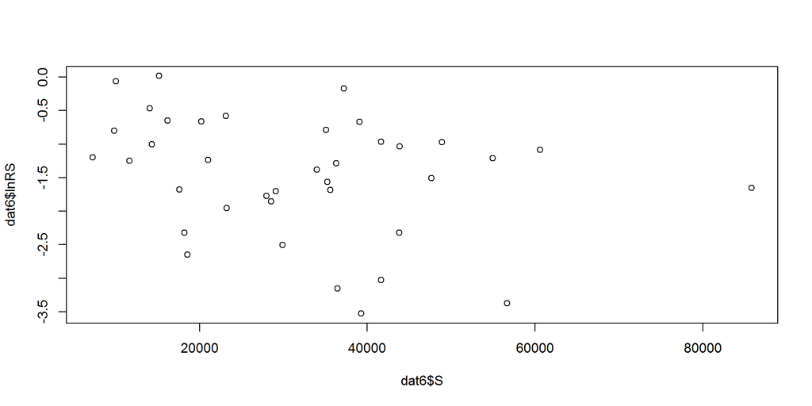

```r
plot(dat6$S, dat6$lnRS)
```

## Mean with residual correlation

Anton called these univariate models.

### Age 4

There may be some residual correlation in the form of a MA1 process. We can use the pred_arima function to get these predictions and save them to our age 4 dataset.

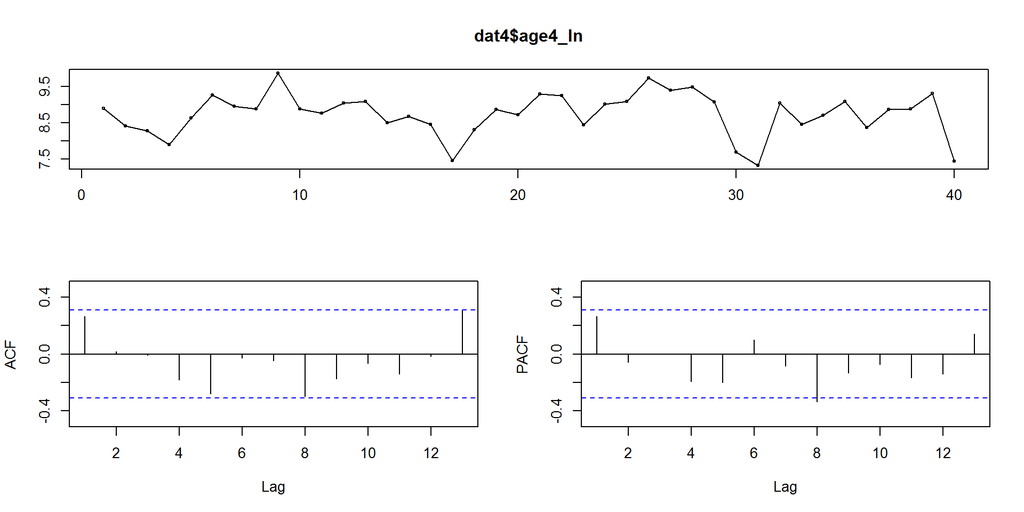

```r
forecast::tsdisplay(dat4$age4_ln)
```

```r
forecast::auto.arima(dat4$age4_ln)
```

```
## Series: dat4$age4_ln
## ARIMA(0,0,1) with non-zero mean
##
## Coefficients:
##          ma1   mean
##       0.3625  8.732
## s.e.  0.1775  0.118
##
## sigma^2 estimated as 0.319:  log likelihood=-32.95
## AIC=71.91   AICc=72.57   BIC=76.97
```

```r
mu4_ma1 <- arima(dat4$age4_ln, order=c(0,0,1))
AIC(mu4_ma1, lm(dat4$age4_ln ~ 1))
```

```
##                      df      AIC
## mu4_ma1               3 71.90721
## lm(dat4$age4_ln ~ 1)  2 73.75239
```

```r
temp <- pred_arima(mu4_ma1, x = dat4$age4_ln)
dat4$mu_pred <- exp(temp[1,] + temp[2,]^2/2)
```

### Age 5

Same as age 4’s.

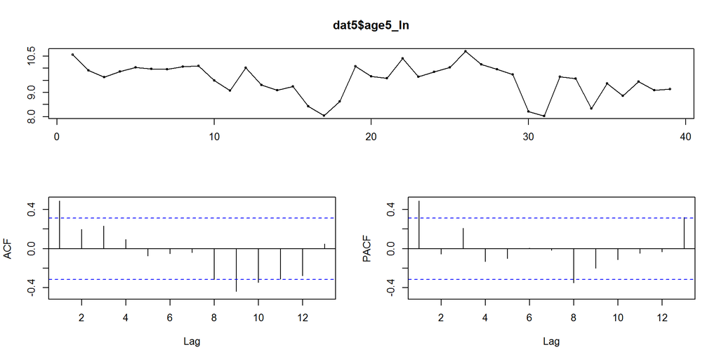

```r
forecast::tsdisplay(dat5$age5_ln)
```

```r
forecast::auto.arima(dat5$age5_ln)
```

```
## Series: dat5$age5_ln
## ARIMA(0,0,1) with non-zero mean
##
## Coefficients:
##          ma1    mean
##       0.5692  9.5261
## s.e.  0.1421  0.1423
##
## sigma^2 estimated as 0.3437:  log likelihood=-33.68
## AIC=73.37   AICc=74.05   BIC=78.36
```

```r
mu5_ma1 <- arima(dat5$age5_ln, order=c(0,0,1))
temp <- pred_arima(mu5_ma1, x = dat5$age5_ln)
dat5$mu_pred <- exp(temp[1,] + temp[2,]^2/2)
```

### Age 6

This time there is a trend and the correlation is AR1.

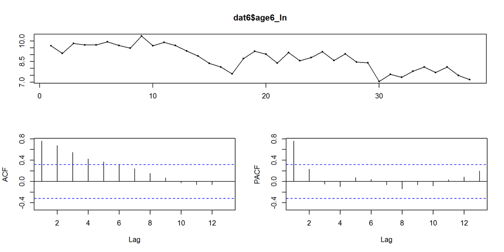

```r
forecast::tsdisplay(dat6$age6_ln)
```

```r
forecast::auto.arima(dat6$age6_ln)
```

```
## Series: dat6$age6_ln
## ARIMA(1,1,0)
##
## Coefficients:
##           ar1
##       -0.3395
## s.e.   0.1549
##
## sigma^2 estimated as 0.2622:  log likelihood=-27.29
## AIC=58.58   AICc=58.93   BIC=61.8
```

```r
mu6_ar1d <- arima(dat6$age6_ln, order=c(1,1,0))
temp <- pred_arima(mu6_ar1d, x = dat6$age6_ln)
dat6$mu_pred <- exp(temp[1,] + temp[2,]^2/2)
```

## Moving average models

This function gives the moving average for a specified number of years. I’ll do a 5 year moving average for each age, and a moving average of all prior years of age 6’s for illustration purposes. Don’t worry about the predictions right now, we’ll see them later. You may want to play with different timeframes.

```r
dat4$ma5_pred <- pred_ma(dat4$age4_ln, yrs = 5)
dat5$ma5_pred <- pred_ma(dat5$age5_ln, yrs = 5)
dat6$ma5_pred <- pred_ma(dat6$age6_ln, yrs = 5)
dat6$ma_pred <- pred_ma(dat6$age6_ln)
```

## Exponential smoothing

Instead of trying to figure out a fixed number of years to include in our moving average we can use a method called exponential smoothing where you take a weighted average of the previous observation and the previous prediction. Since the previous prediction is also a weighted average (of the observation and prediction one year prior) you end up with a moving average where the recent data can be weighted more heavily.

```r
forecast::ets(dat4$age4_ln, "ANN")
```

```
## ETS(A,N,N)
##
## Call:
##  forecast::ets(y = dat4$age4_ln, model = "ANN")
##
##   Smoothing parameters:
##     alpha = 1e-04
##
##   Initial states:
##     l = 8.7428
##
##   sigma:  0.5787
##
##      AIC     AICc      BIC
## 109.7965 110.4632 114.8631
```

```r
dat4$es_pred <- pred_es(dat4$age4_ln)
forecast::ets(dat5$age5_ln, "ANN")
```

```
## ETS(A,N,N)
##
## Call:
##  forecast::ets(y = dat5$age5_ln, model = "ANN")
##
##   Smoothing parameters:
##     alpha = 0.5218
##
##   Initial states:
##     l = 10.2205
##
##   sigma:  0.6167
##
##      AIC     AICc      BIC
## 111.1762 111.8619 116.1669
```

```r
dat5$es_pred <- pred_es(dat5$age5_ln)
forecast::ets(dat6$age6_ln, "ANN")
```

```
## ETS(A,N,N)
##
## Call:
##  forecast::ets(y = dat6$age6_ln, model = "ANN")
##
##   Smoothing parameters:
##     alpha = 0.6757
##
##   Initial states:
##     l = 9.5386
##
##   sigma:  0.5022
##
##      AIC     AICc      BIC
## 91.87812 92.58400 96.79088
```

```r
dat6$es_pred <- pred_es(dat6$age6_ln)
```

## Model Comparison

### Age 4

The function “comp_mods” provides a figure and two statistics to help you decide on the best model. Use md(mean deviation) to assess bias (closest to zero is best) and mad to assess accuracy (smaller is better). In general you want the lowest mad you can get but we will see exceptions.

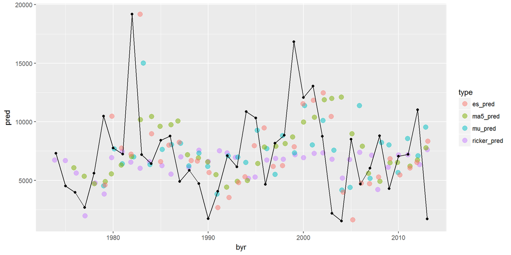

```
##
## [[2]]
## # A tibble: 4 x 3
##          type        md      mad
##         <chr>     <dbl>    <dbl>
## 1     es_pred  398.1659 3289.045
## 2    ma5_pred  503.6737 2820.767
## 3     mu_pred 1533.4281 3656.473
## 4 ricker_pred  639.9582 2514.828
```

```r
comp_models(dat4, 4)
```

### Age 5

A possible exception!

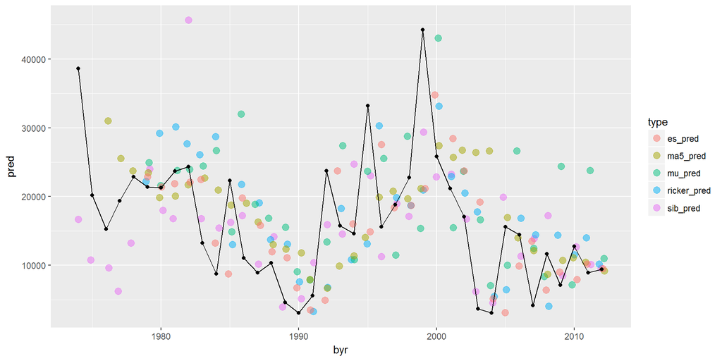

```
##
## [[2]]
## # A tibble: 5 x 3
##          type          md      mad
##         <chr>       <dbl>    <dbl>
## 1     es_pred -1348.77260 2679.265
## 2    ma5_pred    51.22965 1984.754
## 3     mu_pred  4980.91074 8538.075
## 4 ricker_pred   861.67561 4395.417
## 5    sib_pred  1638.04264 1674.049
```

```r
comp_models(dat5, 5)
```

Notice that sib_pred had the lowest mad but the md is almost equal to the mad. This means it almost always missed in the same direction (too high). Normally I’d opt for ma5_pred instead since the mad is similar but the md is close to 0. But close examination of the graphic shows that the sib preds were very close in all but one year. Let’s rerun the comparison only considering the last 4 years of predictions (the default is the last 5).

```r
comp_models(dat5, 5, years = 4)[[2]]
```

```
## # A tibble: 5 x 3
##          type        md      mad
##         <chr>     <dbl>    <dbl>
## 1     es_pred -372.1069 2035.223
## 2    ma5_pred  805.0453 1739.935
## 3     mu_pred 7051.1427 9847.590
## 4 ricker_pred 2978.3747 3592.991
## 5    sib_pred  658.6345  703.642
```

Now the sib_pred model looks like a clear winner. For full disclosure I have no opinion on which model you should choose. I’m just trying to walk through some thought processes.

### Age 6

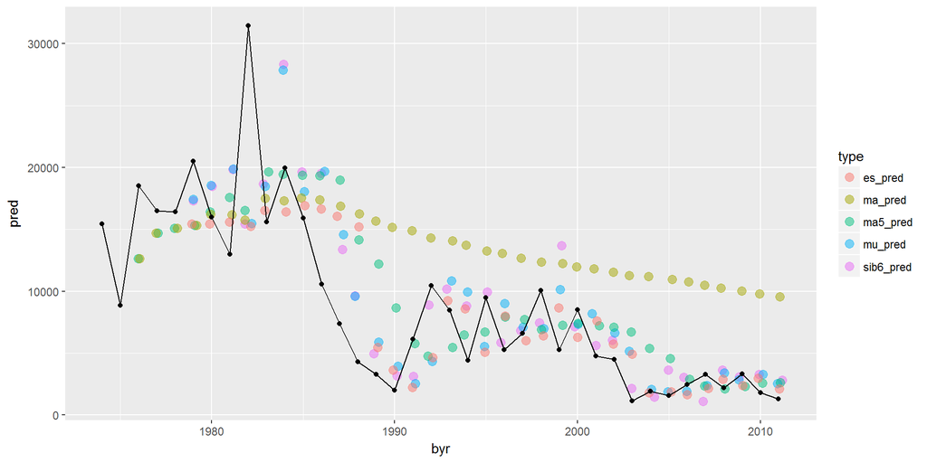

```
##
## [[2]]
## # A tibble: 5 x 3
##        type        md       mad
##       <chr>     <dbl>     <dbl>
## 1   es_pred  129.8481  952.6924
## 2   ma_pred 7638.4248 7638.4248
## 3  ma5_pred   17.8421  832.0567
## 4   mu_pred  515.5138 1057.8664
## 5 sib6_pred  399.2031 1374.3028
```

```r
comp_models(dat6, 6)
```

## 2018 forecast

I’ll try to incorporate next years predictions into the pred_* functions in the future but here are some examples for how to create predictions for the upcoming season.

### Moving average models

```r
ma5 <- function(dat){
  y <- dat[(length(dat) - 4):length(dat)]
  exp(mean(y) + var(y)/2)
}
ma5(dat4$age4_ln)
```

```
## [1] 6810.22
```

```r
ma5(dat5$age5_ln)
```

```
## [1] 10035.51
```

```r
ma5(dat6$age6_ln)
```

```
## [1] 2426.469
```

### Age 4 Ricker

This is a linear model with no autocorrelation, the x variable is the number of spawners for the brood year.

```r
tail(deshka, 7)
```

```
## # A tibble: 7 x 7
##     byr     S  age3  age4  age5  age6  age7
##   <dbl> <dbl> <dbl> <dbl> <dbl> <dbl> <dbl>
## 1  2011 18553  1550  7211  8948  1313    NA
## 2  2012 13952  2897 11021  9391    NA    NA
## 3  2013 18378  4029  1706    NA    NA    NA
## 4  2014 16099  1162    NA    NA    NA    NA
## 5  2015 23627    NA    NA    NA    NA    NA
## 6  2016 22099    NA    NA    NA    NA    NA
## 7  2017 11258    NA    NA    NA    NA    NA
```

```r
exp(predict(rick4, data.frame(S = 16099))) * 16099
```

```
##        1
## 6904.628
```

### Age 5 sibling

This is a linear model with no autocorrelation, the x variables are the natural log of the number of age 4 fish in the brood year and the number of age 3 fish in the brood year.

```r
temp <- predict(sib5, data.frame(age4_ln = log(1706), age3 = 4029), se.fit = TRUE)
exp(temp$fit + temp$se.fit^2/2)
```

```
##        1
## 1262.168
```

### Age 6 sibling

This is a linear model with autocorrelation, the x variable is the natural log of the number of age 5 fish in the brood year.

```r
temp <- predict(sib6_arima, newxreg = log(9391))
exp(temp$pred + temp$se^2/2)
```

```
## Time Series:
## Start = 39
## End = 39
## Frequency = 1
## temp$pred
##  1620.712
```